# TALLER SIMULACION 1

SANTIAGO LOPEZ Y DIEGO MARIN

3/11/2022

## Punto 1

```r
library(nortest)
hembras= c(183.2, 182.5, 166.8, 184.1, 190.0, 196.3, 183.0, 178.1, 173.3, 204.3, 193.2, 187.3, 176.5, 180.4, 185.8, 179.0, 184.3, 189.3, 188.3, 189.2, 195.5, 186.8, 189.1, 202.4, 202.2, 203.1, 210.8)
machos= c(140.9, 173.9, 118.9, 121.7, 177.4, 140.0, 173.8, 154.8, 192.7, 154.5, 177.5, 134.4, 109.2, 153.4, 175.0, 150.7, 138.7, 169.8, 203.3, 136.7, 153.9, 163.0, 165.3, 176.7, 137.7, 126.7, 150.0)
```

## Datos

| Hembras | Machos |
| --- | --- |
| 183.2 182.5, 166.8 | 140.9, 173.9, 118.9 |
| 184.1, 190.0, 196.3 | 121.7, 177.4, 140.0 |
| 183.0, 178.1, 173.3 | 173.8, 154.8, 192.7 |
| 204.3, 193.2, 187.3 | 154.5, 177.5, 134.4 |
| 176.5, 180.4, 185.8 | 109.2, 153.4, 175.0 |
| 179.0, 184.3, 189.3 | 150.7, 138.7, 169.8 |
| 188.3, 189.2, 195.5 | 203.3, 136.7, 153.9 |
| 186.8, 189.1, 202.4 | 163.0, 165.3, 176.7 |
| 202.2, 203.1, 210.8 | 137.7, 126.7, 150.0 |

#### A. Haga un histograma con cinco clases y determine la distribucion de los datos para cada sexo. Explique acerca de la distribucion del tamanioo para cada genero.

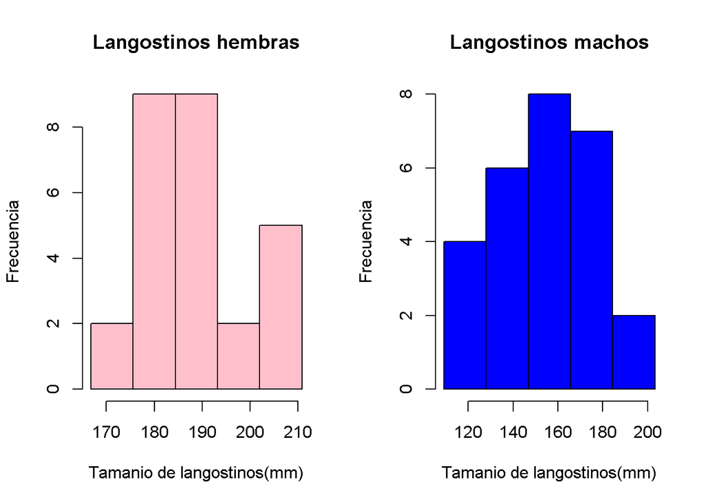

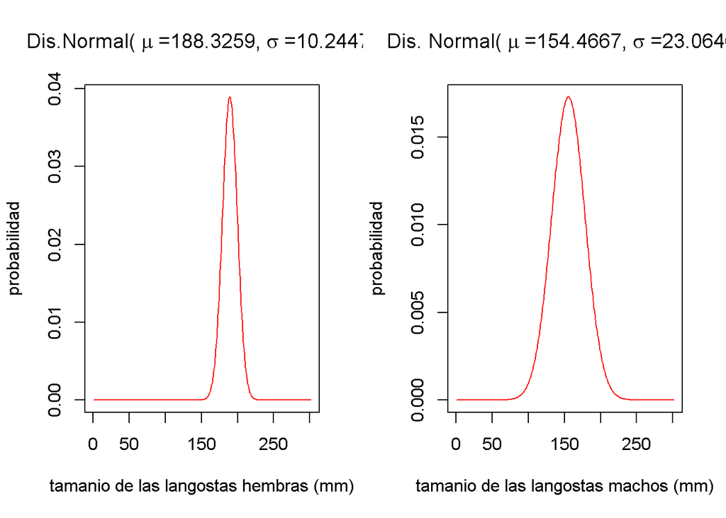

#### B.Hallar el promedio y la desviacion estandar para cada sexo. Que puede concluir?

```r
##media y desviacion estandar de las hembras
mediaHembra= mean(hembras)
dvHembras= sd(hembras)
##media y desviacion estandar de los machos
mediaMachos= mean(machos)
dvMachos= sd(machos)
```

Obteniendo como resultado el promedio del tamanio de las langostas hembra es de 188.3260 mm con una desviacion estandar de mas o menos 10.2447 mm. En cuanto al tamanio de las langostas machos tienen un promedio de 154.4667 mm con una desviacion estandar de mas o menos 23.0646 mm

#### C. Halle un intervalo para la media del Largo total por sexo con un nivel de confianza del 97%. Provea la interpretacion respectiva.

```r
## intervalo de confianza de 97% para las hembras
t.test(x= hembras,mu= mediaHembra, conf.level = 0.97)
```

```
##
##  One Sample t-test
##
## data:  hembras
## t = 0, df = 26, p-value = 1
## alternative hypothesis: true mean is not equal to 188.3259
## 97 percent confidence interval:
##  183.7995 192.8523
## sample estimates:
## mean of x
##  188.3259
```

##### El rango de tamanios de una langosta hembra con un porcentaje de confianza del 97% es desde 183.7995 hasta 192.8523 milimetros

```r
## intervalo de confianza de 97% para los machos
t.test(x= machos,mu= mediaMachos, conf.level = 0.97)
```

```
##
##  One Sample t-test
##
## data:  machos
## t = 0, df = 26, p-value = 1
## alternative hypothesis: true mean is not equal to 154.4667
## 97 percent confidence interval:
##  144.2760 164.6573
## sample estimates:
## mean of x
##  154.4667
```

##### El rango de tamanios de una langosta macho con un porcentaje confianza del 97% es desde 144.2760 hasta 164.6573 milimetros

#### D. Construya un Boxplot por sexo e interpretelo.

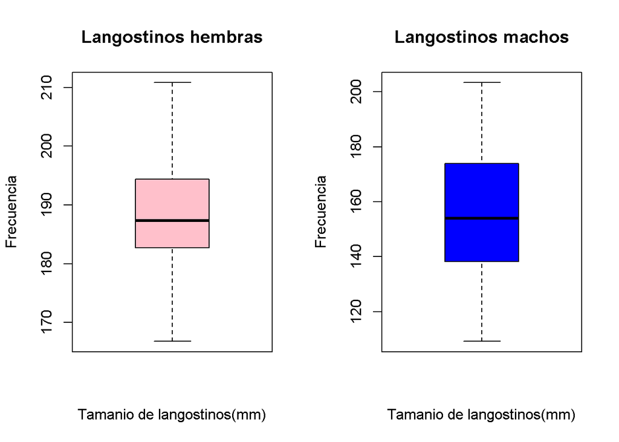

En la anterior grafica de Cajas y Bigotes del tamanio de las langostas en milimetros y separadas por sexo se puede evidenciar que en cuanto a las hembras que tiene un limite inferior entre los 160 y 170 milimetros, que el 50% de los datos estan mas concentrados entre los 182 y 195 milimetros con una media aproximada de 189 milimetros y con un limite superior mayor de 210 y menor de 215 milimetros. En cuanto a los machos se puede notar que el limite inferior esta por debajo de 110 milimetros pero mayor a los 105 milimetros, que el 50% de los datos no estan tan concentrados como los de las hembras pero se encuentran en un intervalo entre 140 y 175 milimetros y con una media entre los 150 y 155 miliemtros, ademas, tienen un limite superior de aproximadamente de 205 milimetros

#### E. Hallar el coeficiente de variacion de ambos sexos e interpretar

```r
##coeficiente de variacion: sigma/media *100 para tener un porcentaje
(dvHembras/mediaHembra)*100
```

```
## [1] 5.439869
```

```r
(dvMachos/mediaMachos)*100
```

```
## [1] 14.93178
```

Dado que el tamanio de las langostas hembras tienen un coeficiente de variación más bajo de 5.4398% con respecto al tamanio de las langostas machos, los cuales tienen un coeficiente de variacion de 14.9318%, quiere decir que los datos de los tamanios de las langostas hembras varian menos que los tamanios de las langostas machos

#### F. Comprobar normalidad

```r
## test de normalidad
sf.test(hembras)
```

```
##
##  Shapiro-Francia normality test
##
## data:  hembras
## W = 0.97544, p-value = 0.6565
```

```r
sf.test(machos)
```

```
##
##  Shapiro-Francia normality test
##
## data:  machos
## W = 0.98377, p-value = 0.8765
```

##### Como el p valor para el tamanio de las langostas hembras (0.6565) es mayor a alfa (0,03), no se rechaza la hipótesis nula (H0), por lo tanto, el tamanio de las langostas hembras presenta un comportamiento normal

##### Como el p valor para el tamanio de las langostas machos (0.8765) es mayor a alfa (0,03), no se rechaza la hipótesis nula (H0), por lo tanto, el tamanio de las langostas machos presenta un comportamiento normal

## Punto 2

En un restaurante de la ciudad se sabe que la probabilidad de que se reciba un billete de $50.000 falso es de 0.015. Si se sabe que en una semana se reciben pagos con 900 billetes de $50.000

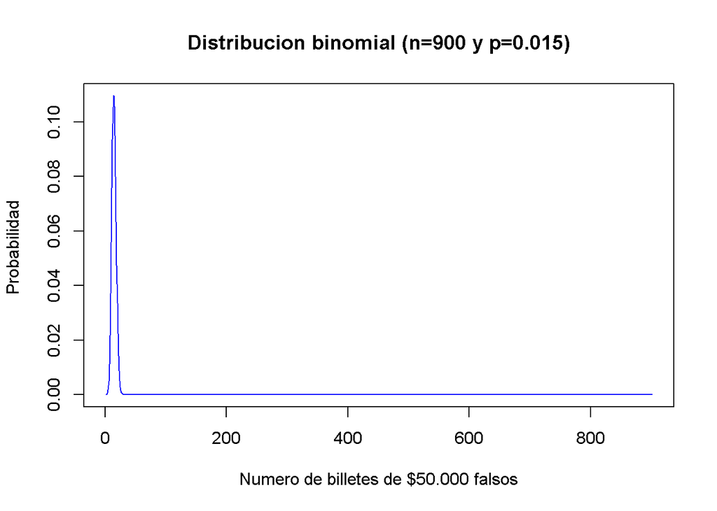

#### A. lo sumo 25 billetes sean falsos.

```r
## X= cantidad de billetes de $50.000 falsos
##cantidad de billetes de $50.000 que se reciben en una semana
n= 900
## probabilidad de que el billete sea falso
p= 0.015

##distribucion Binomial

pbinom(25,n,p,lower.tail = TRUE)
```

```
## [1] 0.9985199
```

La probabilidad de que en una semana a lo sumo reciban 25 billetes de $50.000 falsos es de 0.9985

#### B. La cantidad de billetes falsos este entre 20 y 30.

```r
##distribucion Binomial

pbinom(30,n,p,lower.tail = TRUE) - pbinom(20,n,p,lower.tail = TRUE)
```

```
## [1] 0.03395327
```

La probabilidad de que en una semana reciban entre 20 y 30 billetes de $50.000 falsos es de 0.0340

#### C. Mas de 10 sean falsos.

```r
##distribucion Binomial

pbinom(10,n,p,lower.tail = FALSE)
```

```
## [1] 0.7907816
```

La probabilidad de que en una semana reciban mas de 10 billetes de $50.000 falsos es de 0.7908

## Punto 3

[figure not shown]

#### A. Cuantos de los habitantes de la pequenia ciudad superaran previsiblemente los 92 anios?

```r
##media de la edad de los habitantes de una pequenia ciudad
mu=75
##varianza de la edad de los habitantes de una pequenia ciudad
sigma= 25
## poblacion total
n=100000

##distribucion normal
probabilidad= pnorm(92,mu,sigma, lower.tail = FALSE)

probabilidad * n
```

```
## [1] 24825.22
```

```r
##distribucion normal
probMayor= pnorm(75,mu,sigma, lower.tail = TRUE)
probMenor= pnorm(55,mu,sigma, lower.tail = TRUE)

(probMayor - probMenor)* n
```

```
## [1] 28814.46
```